# STATS 513 Final Project

# 1 Introduction and Data Summary

1. Plot the data using different plotting symbols for the treatment and the control status

check the missingness or entry errors of the data

```r
library(faraway)
library(corrplot)
library(GGally)
library(leaps)
library(MASS)

# 1 Introduction and Data Summary
load("FinalExam.RData")
head(Life_data)
```

```
##    Life.expectancy     Status infant.deaths Alcohol Hepatitis.B  BMI
## 6             58.8 Developing            74    0.01          66 16.7
## 22            76.2 Developing             1    5.28          99 54.3
## 38            74.7 Developing            21    0.45          95 53.9
## 54            49.6 Developing            78    7.80          77  2.4
## 70            75.6 Developing             0    7.84          98 44.4
## 86            75.5 Developing            10    8.15          94 59.8
##    under.five.deaths Polio Diphtheria        GDP Schooling
## 6                102    66         66   553.3289       9.2
## 22                 1    99         99   494.3588      12.5
## 38                24    95         95  4463.3947      13.6
## 54               121    81         77  3529.5348       9.0
## 70                 0    99         98 12126.8761      14.1
## 86                11    95         94  1276.2650      16.8
```

```r
dim(Life_data)
```

```
## [1] 183  11
```

```r
# check the missingness or entry errors of the data
# status is categorical, change it to categorical
Life_data$Status=factor(Life_data$Status)
# after using summary, there are many NA in data, remove these NA rows
Life_data_cleaned=Life_data[complete.cases(Life_data), ]
# after removing all NAs, the data dimensions we have is
dim(Life_data_cleaned)
```

```
## [1] 142  11
```

```r
# now all rows with one or more NAs are removed
# because we know for infant.deaths and under.five.deaths, the number can not exceed 1000, and we found there are some data exceeding 1000, which are clearly errors and need to be removed
Life_data_cleaned=subset(Life_data_cleaned, infant.deaths<=1000|under.five.deaths<=1000)
# after removing data entry errors, the data dimensions we have is
dim(Life_data_cleaned)
```

```
## [1] 141  11
```

```r
# use histograms to see the distribution of data
units=c("(years)"," Developed/Developing","(Number per 1000)"," (litres)","(%)"," ","(Number per 1000)","(%)","(%)","(USD)","(years)")
xlimit=array(c(c(0,100),c(0,100),c(0,1000),c(0,20),c(0,100),c(0,100),c(0,1000),c(0,100),c(0,100),c(0,60000),c(0,25)),dim=c(2,11,1))
```

```r
# Get all varaibles names
variable.names=names(Life_data_cleaned)
variable.names
```

```
##  [1] "Life.expectancy"   "Status"            "infant.deaths"
##  [4] "Alcohol"           "Hepatitis.B"       "BMI"
##  [7] "under.five.deaths" "Polio"             "Diphtheria"
## [10] "GDP"               "Schooling"
```

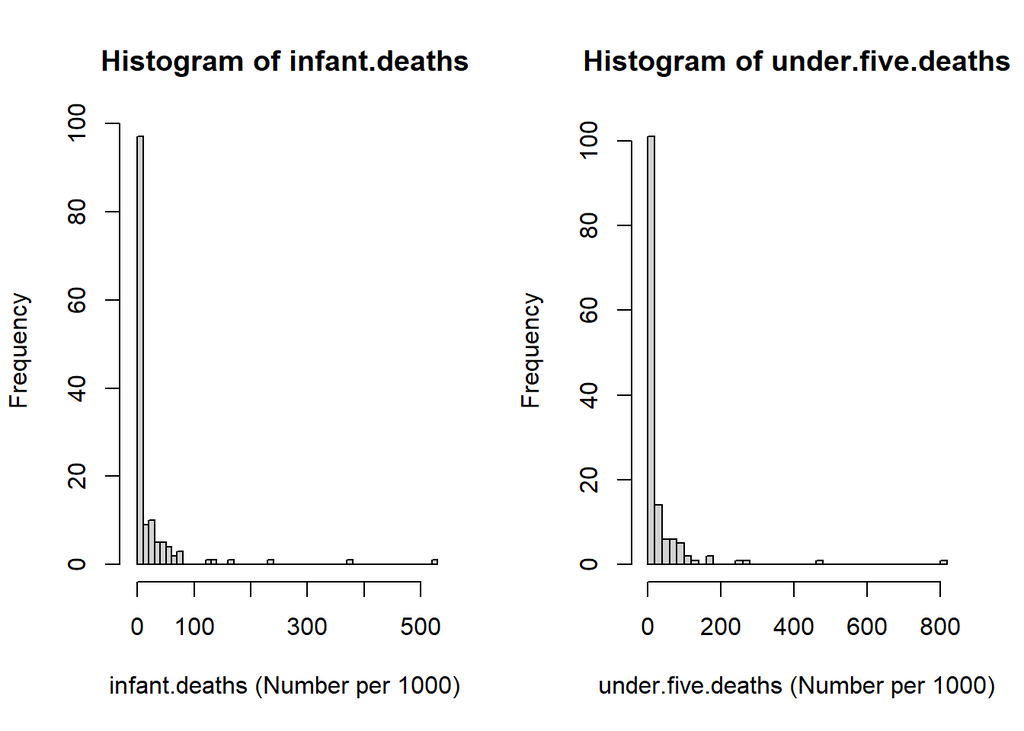

```r
# histograms for infant.deaths and under,five.deaths
par(mfcol=c(1,2))
for(i in c(3,7)){
  hist(Life_data_cleaned[,i], breaks=50, xlab = paste(colnames(Life_data_cleaned)[i],units[i]), main=paste("Histogram of", colnames(Life_data_cleaned)[i], sep=" "), xlim=c(min(Life_data_cleaned[,i])-10,max(Life_data_cleaned[,i])+10))
}
```

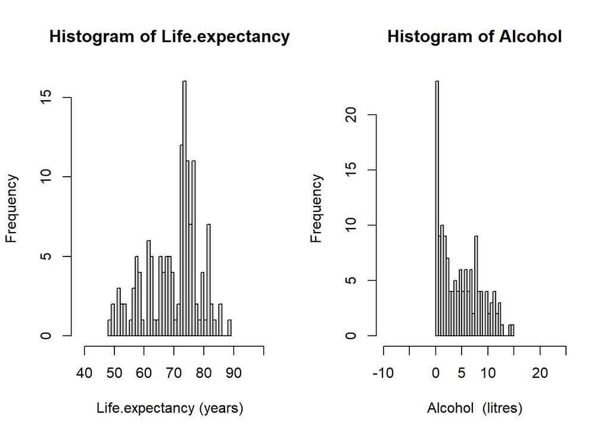

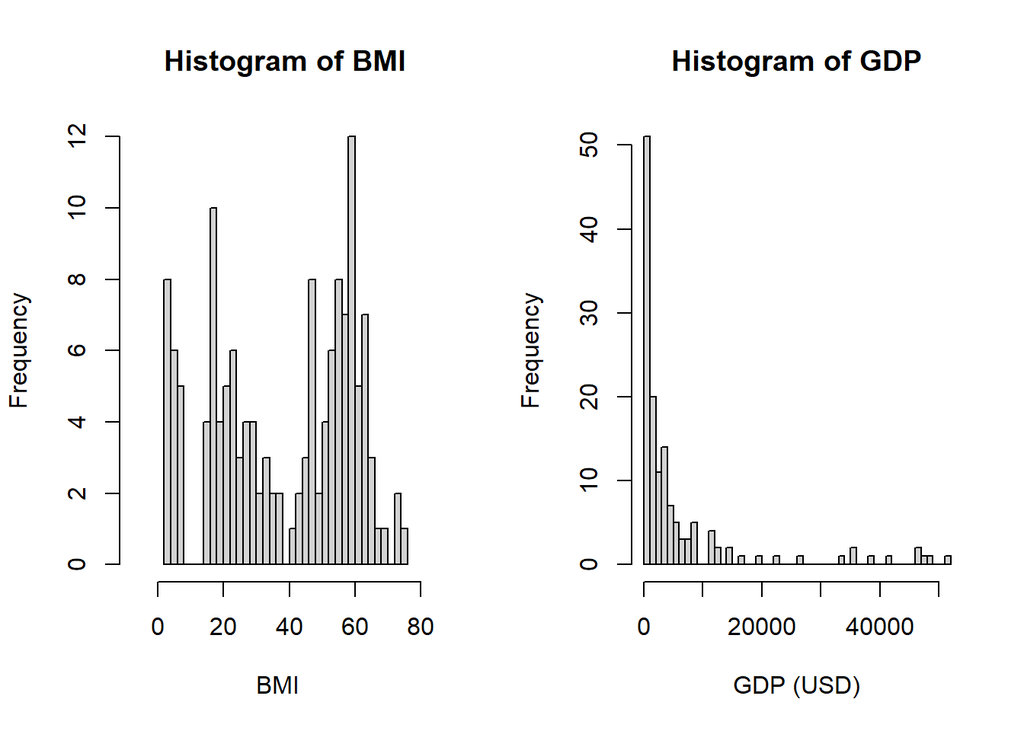

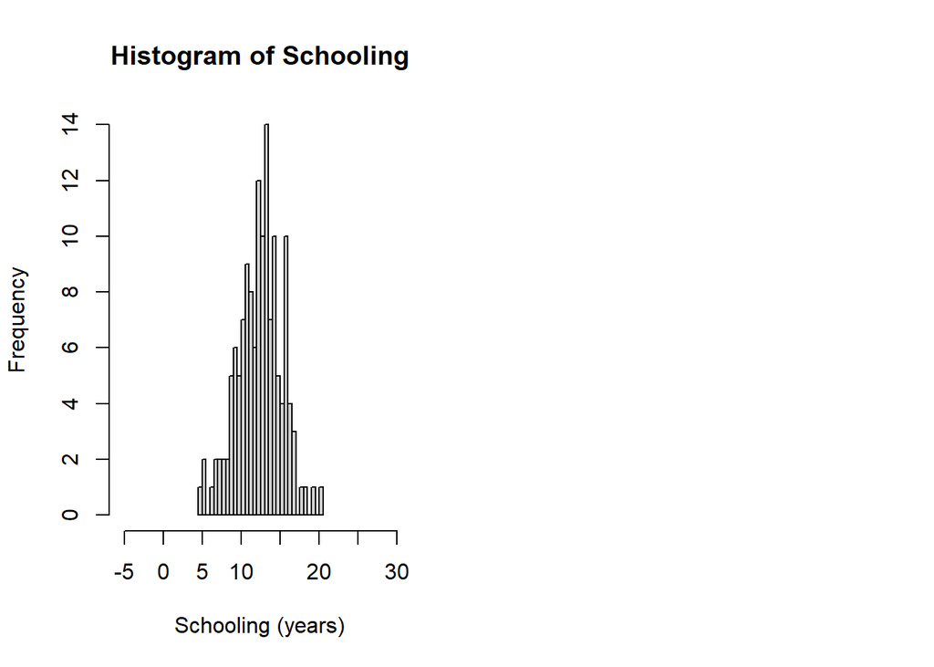

```r
# histograms for Life.expectancy and Alcohol,BMI, schooling,GDP
par(mfcol=c(1,2))
for(i in c(1,4,6,10,11)){
  hist(Life_data_cleaned[,i], breaks=50, xlab = paste(colnames(Life_data_cleaned)[i],units[i]), main=paste("Histogram of", colnames(Life_data_cleaned)[i], sep=" "), xlim=c(min(Life_data_cleaned[,i])-10,max(Life_data_cleaned[,i])+10))
}
```

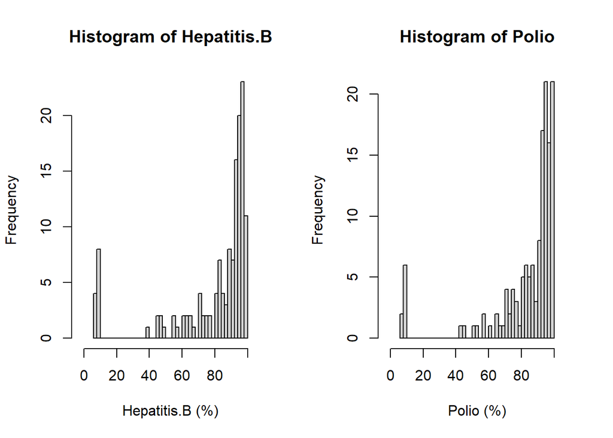

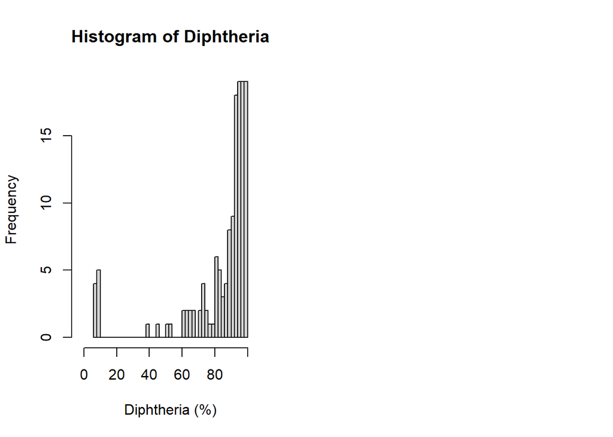

```r
# histograms for Hepatitis.B and Polio,Diphtheria
par(mfcol=c(1,2))
for(i in c(5,8,9)){
  hist(Life_data_cleaned[,i], breaks=50, xlab = paste(colnames(Life_data_cleaned)[i],units[i]), main=paste("Histogram of", colnames(Life_data_cleaned)[i], sep=" "), xlim=c(min(Life_data_cleaned[,i])-10,max(Life_data_cleaned[,i])+10))
}
```

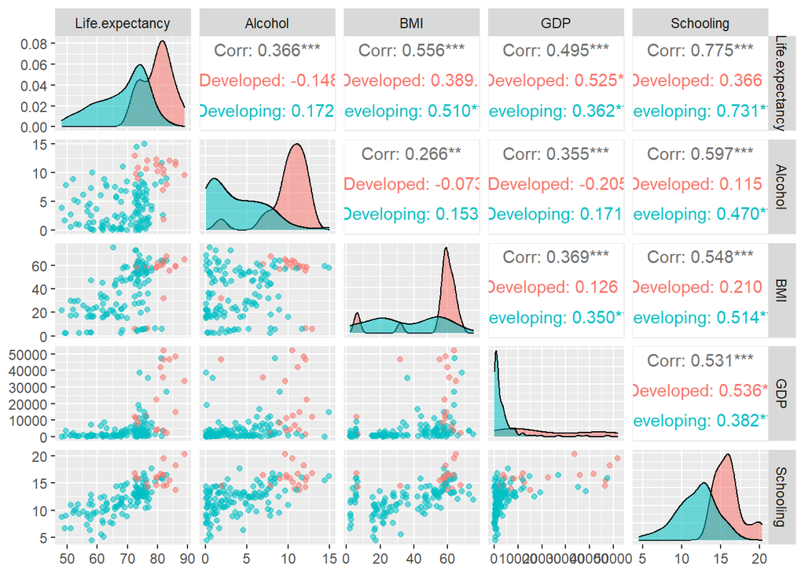

```r
# A Comprehensive Graph
ggpairs(Life_data_cleaned[,c(1,4,6,10,11)],aes(colour=Life_data_cleaned$Status,alpha=0.2))
```

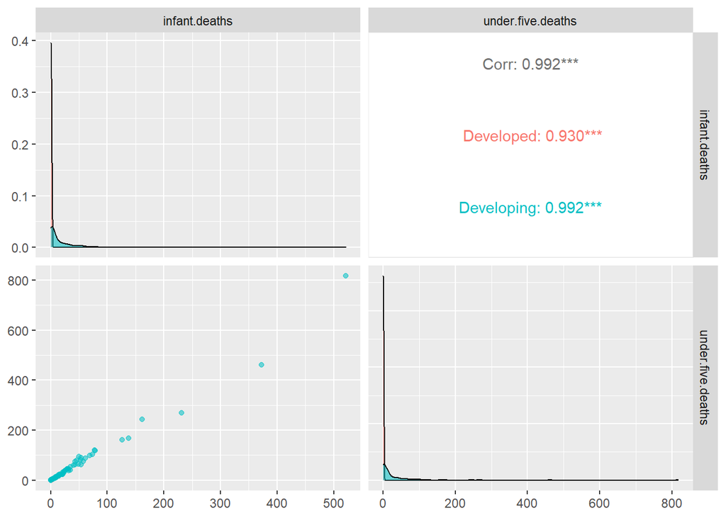

```r
ggpairs(Life_data_cleaned[,c(3,7)],aes(colour=Life_data_cleaned$Status,alpha=0.2))
```

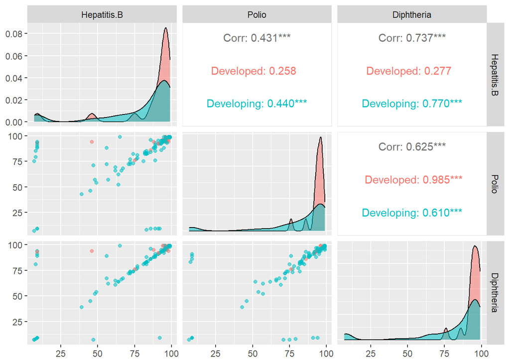

```r
ggpairs(Life_data_cleaned[,c(5,8,9)],aes(colour=Life_data_cleaned$Status,alpha=0.2))
```

report summary statistics

```r
summary(Life_data_cleaned)
```

```
##  Life.expectancy        Status    infant.deaths       Alcohol
##  Min.   :48.1    Developed : 19   Min.   :  0.00   Min.   : 0.010
##  1st Qu.:63.3    Developing:122   1st Qu.:  0.00   1st Qu.: 1.160
##  Median :72.8                     Median :  2.00   Median : 3.950
##  Mean   :69.9                     Mean   : 22.16   Mean   : 4.652
##  3rd Qu.:75.6                     3rd Qu.: 20.00   3rd Qu.: 7.580
##  Max.   :89.0                     Max.   :521.00   Max.   :14.970
##   Hepatitis.B         BMI        under.five.deaths     Polio
##  Min.   : 7.00   Min.   : 2.20   Min.   :  0.00    Min.   : 7.00
##  1st Qu.:76.00   1st Qu.:19.80   1st Qu.:  1.00    1st Qu.:82.00
##  Median :92.00   Median :43.90   Median :  3.00    Median :94.00
##  Mean   :80.48   Mean   :38.02   Mean   : 30.87    Mean   :84.13
##  3rd Qu.:96.00   3rd Qu.:57.50   3rd Qu.: 24.00    3rd Qu.:97.00
##  Max.   :99.00   Max.   :75.20   Max.   :817.00    Max.   :99.00
##    Diphtheria         GDP             Schooling
##  Min.   : 7.00   Min.   :    8.38   Min.   : 4.5
##  1st Qu.:82.00   1st Qu.:  595.00   1st Qu.:10.6
##  Median :93.00   Median : 1932.86   Median :12.7
##  Mean   :83.79   Mean   : 6300.55   Mean   :12.4
##  3rd Qu.:97.00   3rd Qu.: 5451.67   3rd Qu.:14.3
##  Max.   :99.00   Max.   :51874.85   Max.   :20.3
```

By seeing the histograms of each variable, we can get a sense of the distribution of each variables. There could be potentially more errors. For example, in infant deaths and under five deaths,there a few observations with exceptionally high values, some are 500 or 800, which seem to be impossible. And for Hepatitis.B, Polio and Diphtheria, most of the values are close to 100, but there are a few exceptionally small values, which are also doubtful. And the BMI values are very strange, as I looked up online and find nearly all countries’ average BMIs are between 20 and 30. The BMI here could be of different units or calculation methods.These could potentially lead to the inaccuracy of our results.

separate the cleaned dataset into training dataset and testing dataset

```r
train_data<-Life_data_cleaned[1:115,]
dim(train_data)
```

```
## [1] 115  11
```

```r
test_data<-Life_data_cleaned[-c(1:115),]
dim(test_data)
```

```
## [1] 26 11
```

```r
p_tr=dim(train_data)[2]-1
p_tr
```

```
## [1] 10
```

```r
n_tr=dim(train_data)[1]
n_tr
```

```
## [1] 115
```

```r
# do data summary for training dataset and etsting dataset separately
summary(train_data)
```

```
##  Life.expectancy        Status   infant.deaths      Alcohol
##  Min.   :49.20   Developed :17   Min.   :  0.0   Min.   : 0.010
##  1st Qu.:63.80   Developing:98   1st Qu.:  0.0   1st Qu.: 0.995
##  Median :73.00                   Median :  2.0   Median : 4.160
##  Mean   :70.32                   Mean   : 24.5   Mean   : 4.825
##  3rd Qu.:75.80                   3rd Qu.: 20.5   3rd Qu.: 7.910
##  Max.   :89.00                   Max.   :521.0   Max.   :14.970
##   Hepatitis.B         BMI        under.five.deaths     Polio
##  Min.   : 7.00   Min.   : 2.20   Min.   :  0.00    Min.   : 7.00
##  1st Qu.:77.00   1st Qu.:18.15   1st Qu.:  1.00    1st Qu.:82.00
##  Median :93.00   Median :44.40   Median :  3.00    Median :93.00
##  Mean   :81.66   Mean   :37.88   Mean   : 34.07    Mean   :83.77
##  3rd Qu.:96.00   3rd Qu.:57.65   3rd Qu.: 24.00    3rd Qu.:97.00
##  Max.   :99.00   Max.   :75.20   Max.   :817.00    Max.   :99.00
##    Diphtheria         GDP             Schooling
##  Min.   : 7.00   Min.   :    8.38   Min.   : 4.50
##  1st Qu.:82.50   1st Qu.:  608.92   1st Qu.:10.45
##  Median :94.00   Median : 2178.92   Median :12.70
##  Mean   :84.84   Mean   : 6697.46   Mean   :12.40
##  3rd Qu.:97.00   3rd Qu.: 6094.51   3rd Qu.:14.35
##  Max.   :99.00   Max.   :51874.85   Max.   :20.30
```

```r
summary(test_data)
```

```
##  Life.expectancy        Status   infant.deaths      Alcohol
##  Min.   :48.10   Developed : 2   Min.   : 0.00   Min.   : 0.100
##  1st Qu.:60.25   Developing:24   1st Qu.: 0.00   1st Qu.: 1.333
##  Median :70.40                   Median : 3.00   Median : 2.605
##  Mean   :68.05                   Mean   :11.81   Mean   : 3.887
##  3rd Qu.:74.15                   3rd Qu.:18.50   3rd Qu.: 6.145
##  Max.   :82.00                   Max.   :79.00   Max.   :10.030
##   Hepatitis.B         BMI        under.five.deaths     Polio
##  Min.   : 8.00   Min.   : 2.70   Min.   :  0.00    Min.   : 8.00
##  1st Qu.:71.25   1st Qu.:23.25   1st Qu.:  0.25    1st Qu.:83.25
##  Median :87.50   Median :39.30   Median :  4.00    Median :94.00
##  Mean   :75.27   Mean   :38.65   Mean   : 16.73    Mean   :85.69
##  3rd Qu.:96.00   3rd Qu.:55.55   3rd Qu.: 22.50    3rd Qu.:96.75
##  Max.   :99.00   Max.   :72.70   Max.   :119.00    Max.   :99.00
##    Diphtheria         GDP             Schooling
##  Min.   : 8.00   Min.   :   45.13   Min.   : 8.70
##  1st Qu.:74.50   1st Qu.:  624.66   1st Qu.:11.00
##  Median :91.00   Median : 1420.52   Median :12.45
##  Mean   :79.12   Mean   : 4545.00   Mean   :12.44
##  3rd Qu.:96.75   3rd Qu.: 3548.76   3rd Qu.:13.45
##  Max.   :99.00   Max.   :46569.68   Max.   :16.40
```

comment the collinearity between predictors in the training dataset

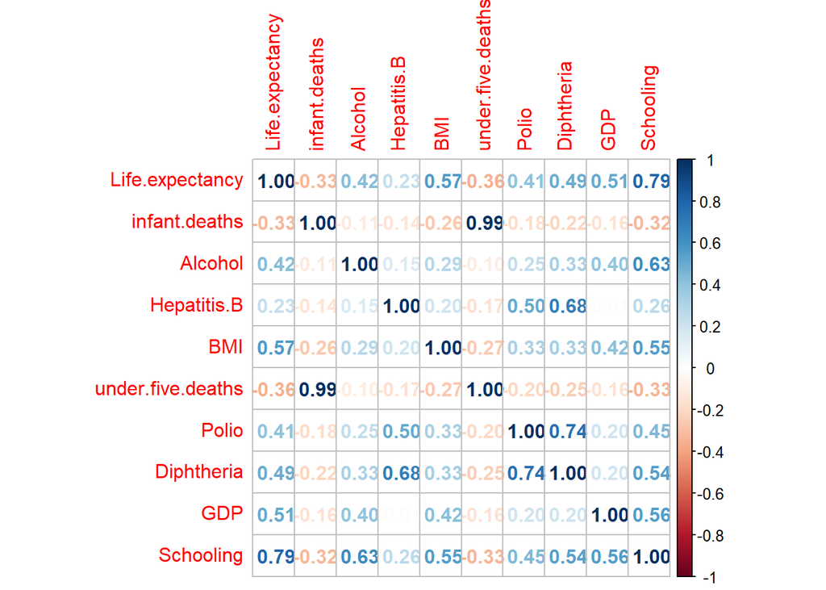

```r
result <- lm(Life.expectancy ~ ., data=train_data)
# check correlation matrix
plot=cor(train_data[-1,-2])
corrplot(plot,method = 'number')
```

```r
# check condition number
X=model.matrix(result)[,c(-1,-2)]
e <- eigen(t(X) %*% X)
e$val
```

```
## [1] 2.023786e+10 2.416627e+06 1.290908e+06 3.790568e+04 2.950858e+04
## [6] 1.135324e+04 5.662495e+03 1.521301e+03 5.019237e+02
```

```r
round(sqrt(e$val[1]/e$val), 3)
```

```
## [1]    1.000   91.512  125.209  730.685  828.148 1335.126 1890.507 3647.328
## [9] 6349.850
```

```r
# check variance inflation factor
round(sort(vif(X),decreasing=TRUE), 3)
```

```
## under.five.deaths     infant.deaths        Diphtheria         Schooling
##            67.299            66.049             3.726             3.213
##             Polio       Hepatitis.B           Alcohol               GDP
##             2.291             2.014             1.810             1.572
##               BMI
##             1.553
```

We can see there are some predictors that are highly correlated. under.five.deaths and infant.deaths has a correlation of 0.99, we may remove one of them in the following analysis. Diphtheria and Polio have a high correlation value of 0.74. Diphtheria and Hepatitis B have a high correlation value of 0.68. Schooling and Life.expectancy has a correlation value of 0.79.We may delete some of those highly correlated predictors, because some of them are of the same category. For example, Diphtheria, Hepatitis.B, Polio are all immunization coverage. infant.deaths and under.five.deaths are all child death rates. They are supposed to have similar values are thus are highly correlated.Variance inflation factor is defined by $VIF=\frac{1}{1-R^2_j}$, which is related to the R squared of this predictor regressed on other predictors. When $R^2_j$ is close to 1, indicating this predictor can be linearly represented by other predictors, and the VIF will be very large, we can see here infant.deaths and under.five.deaths have very large VIFs. they also has the biggest correlation values. For conditional numbers, >30 is considered large and highly collinear. The conditional number here is 6349.850.

# 2 Data Analysis

# 2.1 Data Analysis A.1

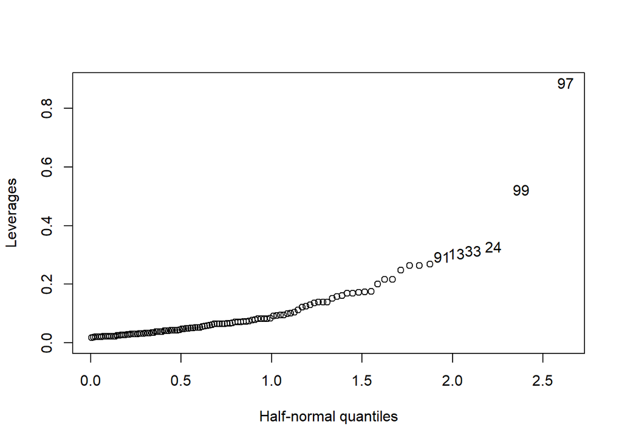

```r
# check for leverage points
halfnorm(lm.influence(result)$hat, nlab = 6,ylab="Leverages")
```

97 and 99 observation is likely to be high leverage points because their X matrix rows have exceptional different (large or small) values.

```r
# check for outliers
## Compute studentized residuals
ti <- rstudent(result)
sorted_ti=sort(ti,decreasing=TRUE)
## Compute p-value
sorted_ti_p=2*(1-pt(abs(sorted_ti), df=n_tr-p_tr-1))
## compare to alpha/n
0.05/n_tr
```

```
## [1] 0.0004347826
```

```r
sum(sorted_ti_p<(0.05/n_tr))
```

```
## [1] 0
```

Using the Bonferroni correction, we can see that there is no observation whose studentized residual has a smaller p value than 0.05/n_tr. This indicates that none of the observation is outlier.

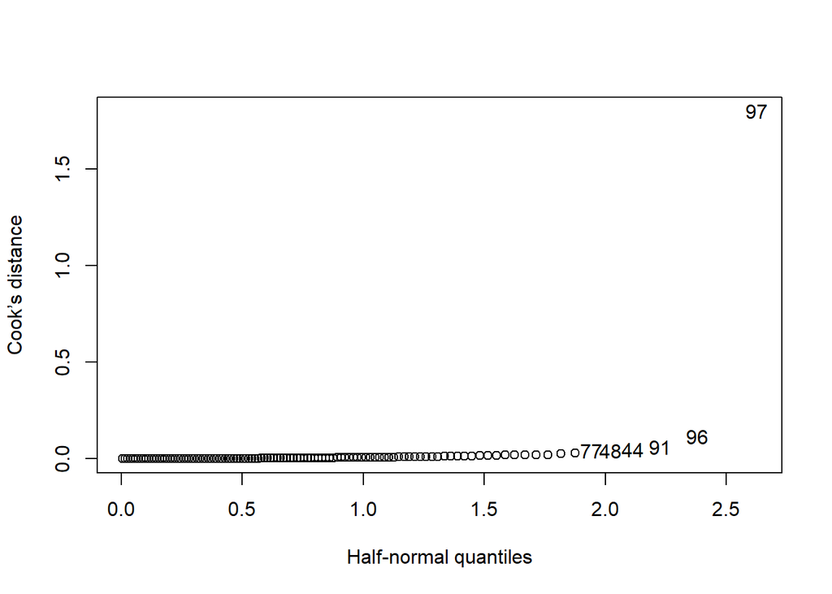

```r
# check for influential points
cook <- cooks.distance(result)
halfnorm(cook, nlab = 6, ylab="Cook’s distance")
```

```r
country <- row.names(train_data)
country[97]
```

```
## [1] "1899"
```

We can see the 97th observation, which has the index 1899, has the highest cook’s distance, indicating it is an influential point.

After the operation above, we may consider exclude 99th and 97th observation in the analysis as they may be leverage points or influential points.

```r
# remove 97th and 99th observations
dim(train_data)
```

```
## [1] 115  11
```

```r
train_data=train_data[c(-97,-99),]
dim(train_data)
```

```
## [1] 113  11
```

```r
# first try linear model
model_linear=lm(Life.expectancy ~., train_data)
summary(model_linear)
```

```
##
## Call:
## lm(formula = Life.expectancy ~ ., data = train_data)
##
## Residuals:
##      Min       1Q   Median       3Q      Max
## -16.4234  -2.8418   0.0844   2.9835  10.1985
##
## Coefficients:
##                     Estimate Std. Error t value Pr(>|t|)
## (Intercept)        5.096e+01  3.951e+00  12.898  < 2e-16 ***
## StatusDeveloping  -3.096e+00  1.782e+00  -1.738  0.08531 .
## infant.deaths      2.842e-01  1.040e-01   2.731  0.00743 **
## Alcohol           -2.405e-01  1.688e-01  -1.425  0.15730
## Hepatitis.B       -2.432e-02  2.696e-02  -0.902  0.36913
## BMI                5.509e-02  2.723e-02   2.023  0.04569 *
## under.five.deaths -2.235e-01  8.099e-02  -2.759  0.00686 **
## Polio             -8.464e-03  3.092e-02  -0.274  0.78485
## Diphtheria         4.731e-02  4.171e-02   1.134  0.25931
## GDP                5.245e-05  5.330e-05   0.984  0.32740
## Schooling          1.601e+00  2.883e-01   5.555 2.22e-07 ***
## ---
## Signif. codes:  0 '***' 0.001 '**' 0.01 '*' 0.05 '.' 0.1 ' ' 1
##
## Residual standard error: 4.918 on 102 degrees of freedom
## Multiple R-squared:  0.7029, Adjusted R-squared:  0.6737
## F-statistic: 24.13 on 10 and 102 DF,  p-value: < 2.2e-16
```

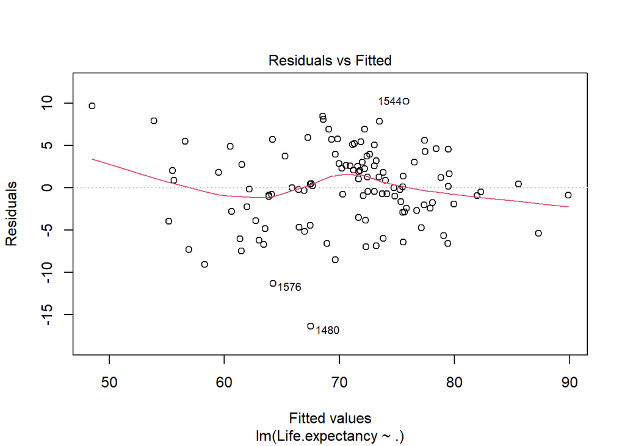

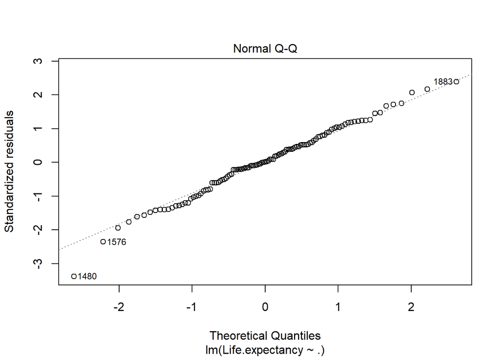

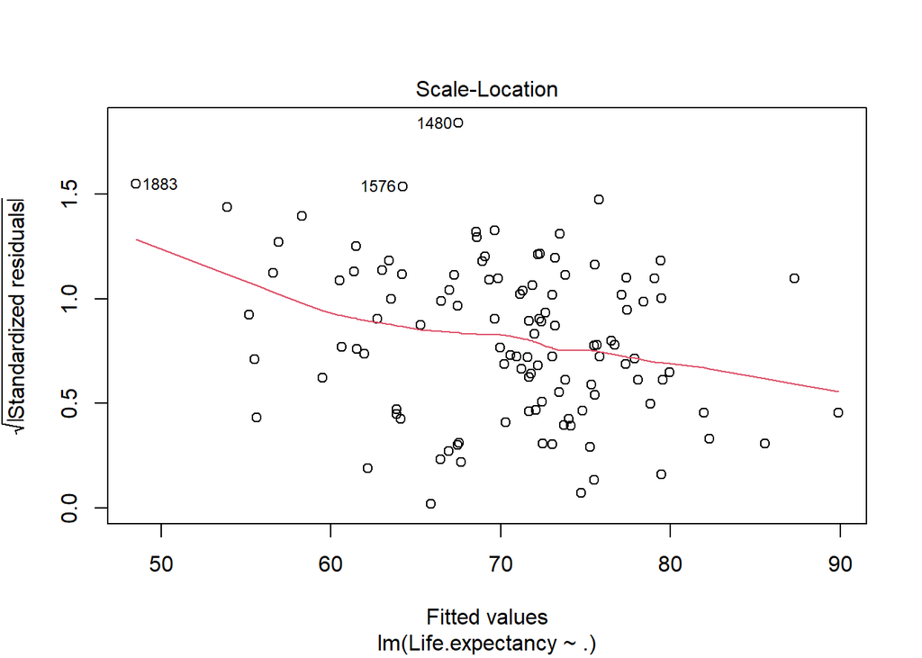

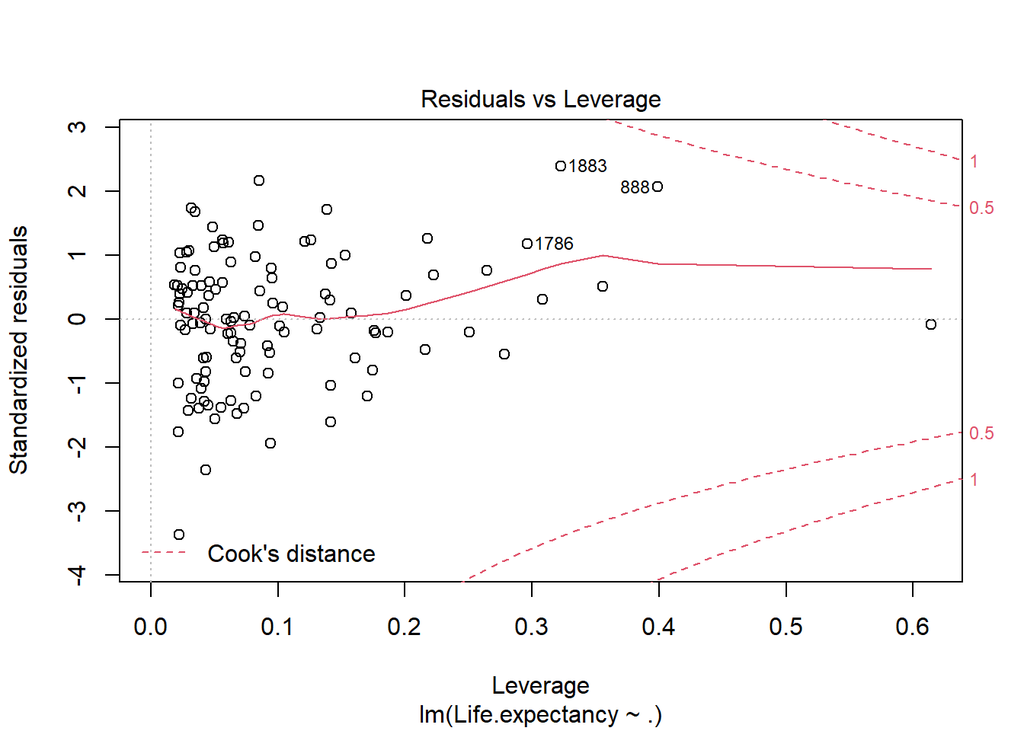

```r
plot(model_linear)
```

```r
summary(lm(sqrt(abs(model_linear$residuals))~model_linear$fitted.value))
```

```
##
## Call:
## lm(formula = sqrt(abs(model_linear$residuals)) ~ model_linear$fitted.value)
##
## Residuals:
##      Min       1Q   Median       3Q      Max
## -1.81636 -0.57091  0.03306  0.61017  2.23212
##
## Coefficients:
##                           Estimate Std. Error t value Pr(>|t|)
## (Intercept)                3.63831    0.72152   5.043  1.8e-06 ***
## model_linear$fitted.value -0.02692    0.01018  -2.645  0.00934 **
## ---
## Signif. codes:  0 '***' 0.001 '**' 0.01 '*' 0.05 '.' 0.1 ' ' 1
##
## Residual standard error: 0.7774 on 111 degrees of freedom
## Multiple R-squared:  0.0593, Adjusted R-squared:  0.05083
## F-statistic: 6.998 on 1 and 111 DF,  p-value: 0.009345
```

We find that in this model, the parameter of infant.deaths is positive, which indicates more infant deaths lead to higher life expectancy. This is unlikely, and is probably because infant.deaths and under.five.deaths is highly correlated, thus the estimated parameters have a big variance and are unstable. infant.deaths and under.five.deaths are both significant. The significance could be fake as there are collinearity. The QQ plot may indicate the distribution of errors is long tailed. And errors are more likely to have extreme values. We may consider robust methods. The square root of standardized residuals suggest it is linearly related to the fitted values. This suggests we may need to do transformation for the response. Heteroscadesticity observed.

```r
# partial regression plot
variable.names(train_data)
```

```
##  [1] "Life.expectancy"   "Status"            "infant.deaths"
##  [4] "Alcohol"           "Hepatitis.B"       "BMI"
##  [7] "under.five.deaths" "Polio"             "Diphtheria"
## [10] "GDP"               "Schooling"
```

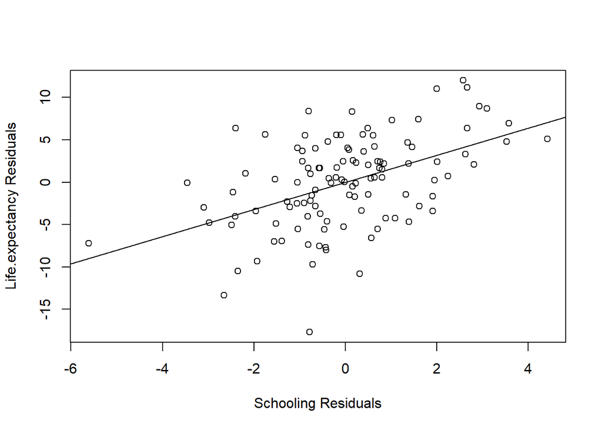

```r
delta <- residuals(lm(Life.expectancy ~.-Schooling, data=train_data))
gamma <- residuals(lm(Schooling ~ .-Schooling-Life.expectancy, data=train_data))
plot(gamma,delta, xlab="Schooling Residuals",ylab="Life.expectancy Residuals")
temp <- lm(delta ~ gamma)
abline(reg=temp)
```

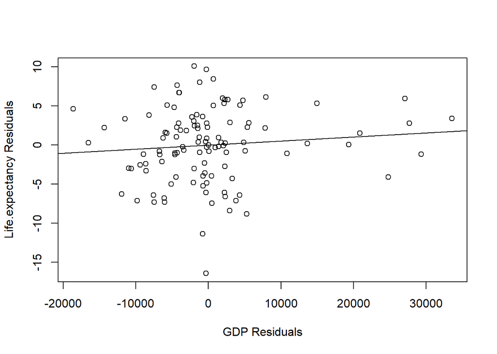

```r
delta <- residuals(lm(Life.expectancy ~.-GDP, data=train_data))
gamma <- residuals(lm(GDP ~ .-GDP-Life.expectancy, data=train_data))
plot(gamma,delta, xlab="GDP Residuals",ylab="Life.expectancy Residuals")
temp <- lm(delta ~ gamma)
abline(reg=temp)
```

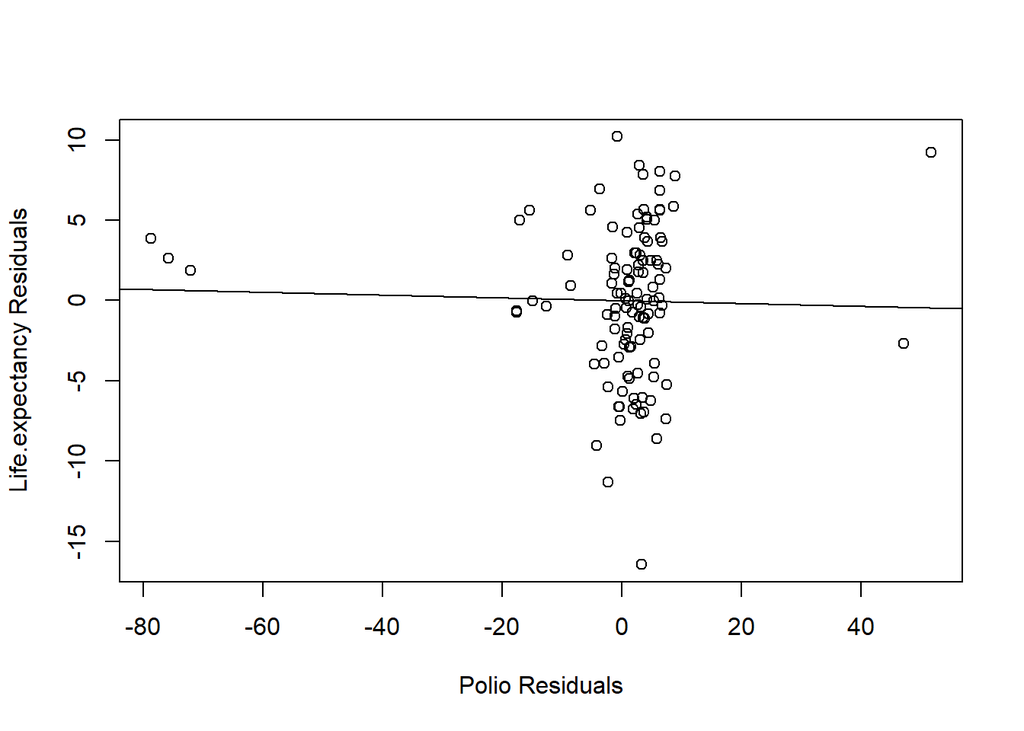

```r
delta <- residuals(lm(Life.expectancy ~.-Polio, data=train_data))
gamma <- residuals(lm(Polio ~ .-Polio-Life.expectancy, data=train_data))
plot(gamma,delta, xlab="Polio Residuals",ylab="Life.expectancy Residuals")
temp <- lm(delta ~ gamma)
abline(reg=temp)
```

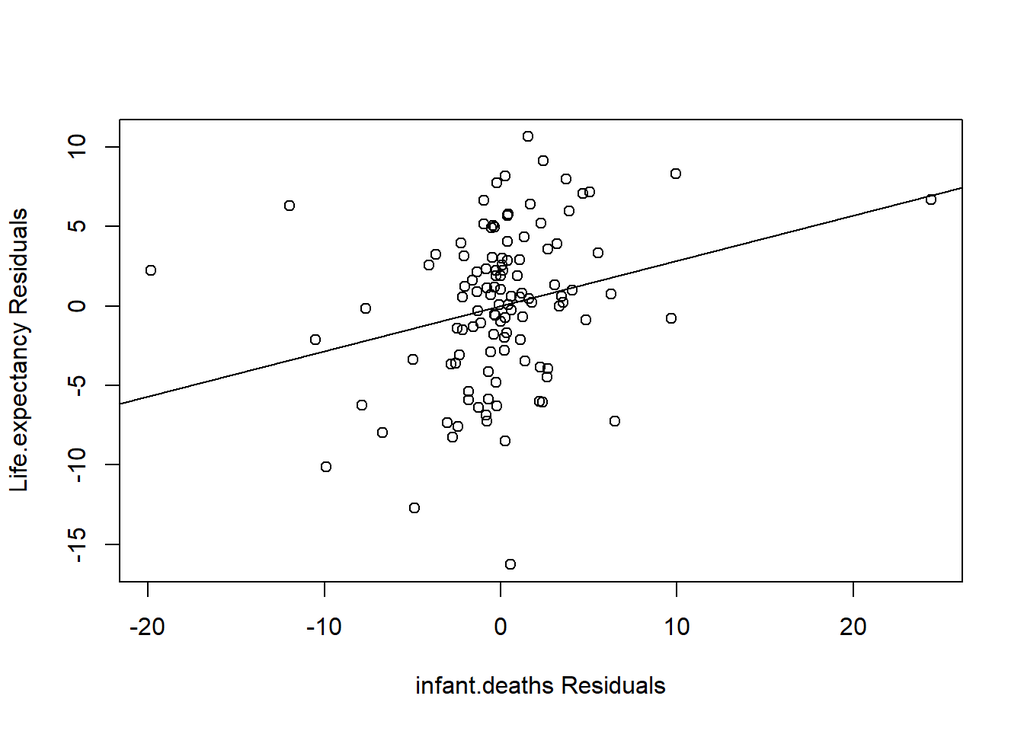

```r
delta <- residuals(lm(Life.expectancy ~.-infant.deaths, data=train_data))
gamma <- residuals(lm(infant.deaths ~ .-infant.deaths-Life.expectancy, data=train_data))
plot(gamma,delta, xlab="infant.deaths Residuals",ylab="Life.expectancy Residuals")
temp <- lm(delta ~ gamma)
abline(reg=temp)
```

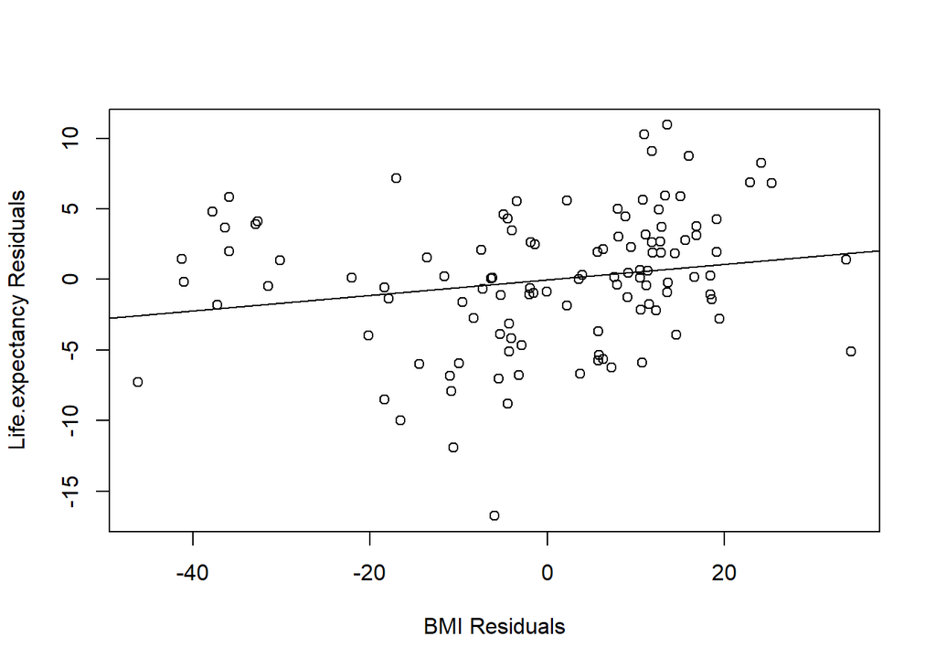

```r
delta <- residuals(lm(Life.expectancy ~.-BMI, data=train_data))
gamma <- residuals(lm(BMI ~ .-BMI-Life.expectancy, data=train_data))
plot(gamma,delta, xlab="BMI Residuals",ylab="Life.expectancy Residuals")
temp <- lm(delta ~ gamma)
abline(reg=temp)
```

We will drop under.five.deaths because it it highly correlated with infant.deaths.Try Box Cox transformation

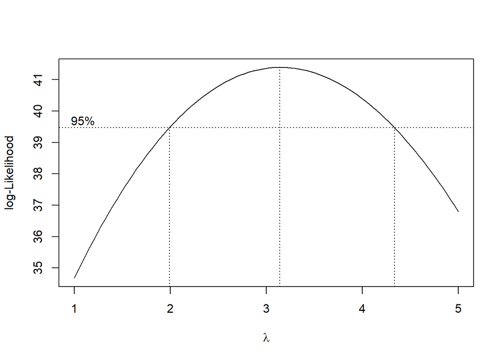

```r
g = lm(Life.expectancy ~.-under.five.deaths, train_data)
boxcox(g, plotit=T, lambda=seq(1, 5, by=0.1))
```

We can see the 95% confidence interval does not contain 1, there is need to do Box Cox transformation. We will set the lambda to 3. I choose not to do transformation on predictors because there are too many predictors.

```r
model_boxcox=lm(Life.expectancy^(3) ~ .-under.five.deaths, data=train_data)
summary(model_boxcox)
```

```
##
## Call:
## lm(formula = Life.expectancy^(3) ~ . - under.five.deaths, data = train_data)
##
## Residuals:
##     Min      1Q  Median      3Q     Max
## -181209  -49020    -593   43199  186770
##
## Coefficients:
##                    Estimate Std. Error t value Pr(>|t|)
## (Intercept)       4.703e+04  4.881e+04   0.964   0.3376
## StatusDeveloping -5.269e+04  2.538e+04  -2.076   0.0403 *
## infant.deaths     1.096e+01  2.114e+02   0.052   0.9587
## Alcohol          -3.617e+03  2.397e+03  -1.509   0.1343
## Hepatitis.B      -4.440e+02  3.830e+02  -1.159   0.2490
## BMI               7.704e+02  3.874e+02   1.989   0.0494 *
## Polio            -1.328e+02  4.417e+02  -0.301   0.7643
## Diphtheria        9.133e+02  5.946e+02   1.536   0.1276
## GDP               1.128e+00  7.573e-01   1.489   0.1394
## Schooling         2.518e+04  3.844e+03   6.550  2.3e-09 ***
## ---
## Signif. codes:  0 '***' 0.001 '**' 0.01 '*' 0.05 '.' 0.1 ' ' 1
##
## Residual standard error: 70240 on 103 degrees of freedom
## Multiple R-squared:  0.7016, Adjusted R-squared:  0.6755
## F-statistic:  26.9 on 9 and 103 DF,  p-value: < 2.2e-16
```

```r
summary(lm(sqrt(abs(model_boxcox$residuals))~model_boxcox$fitted.value))
```

```
##
## Call:
## lm(formula = sqrt(abs(model_boxcox$residuals)) ~ model_boxcox$fitted.value)
##
## Residuals:
##      Min       1Q   Median       3Q      Max
## -188.964  -62.414    3.361   73.188  224.431
##
## Coefficients:
##                             Estimate Std. Error t value Pr(>|t|)
## (Intercept)                2.183e+02  3.344e+01   6.528 2.07e-09 ***
## model_boxcox$fitted.value -2.353e-05  8.795e-05  -0.268     0.79
## ---
## Signif. codes:  0 '***' 0.001 '**' 0.01 '*' 0.05 '.' 0.1 ' ' 1
##
## Residual standard error: 96.14 on 111 degrees of freedom
## Multiple R-squared:  0.0006445,  Adjusted R-squared:  -0.008359
## F-statistic: 0.07159 on 1 and 111 DF,  p-value: 0.7895
```

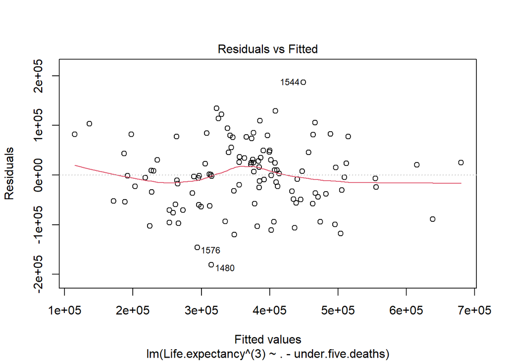

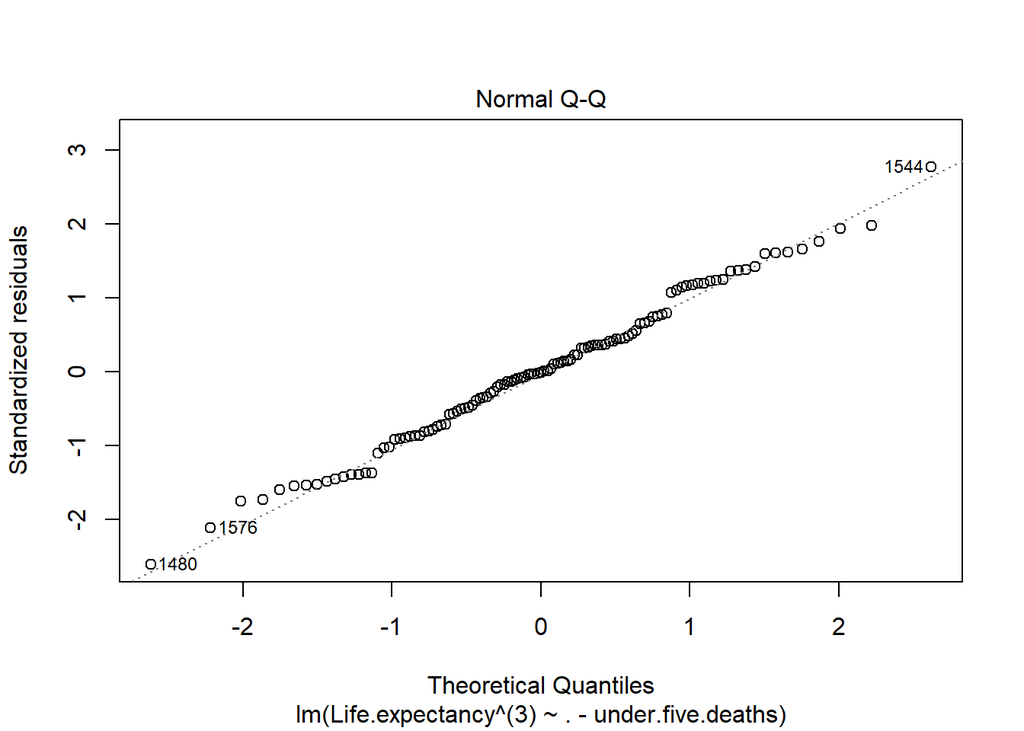

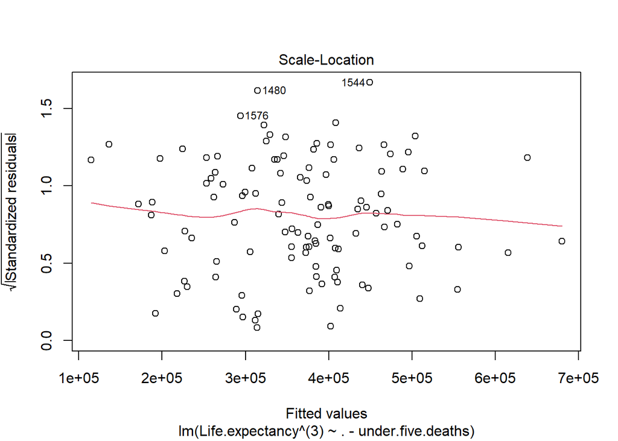

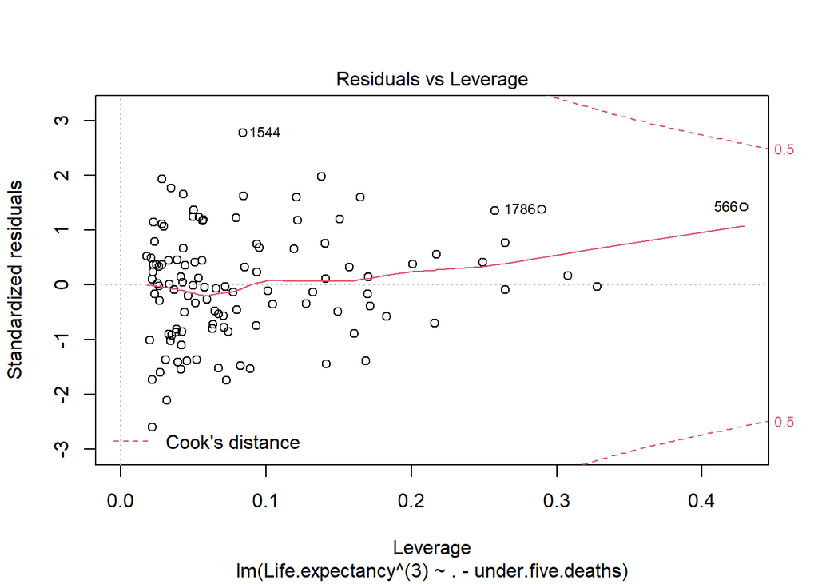

```r
plot(model_boxcox)
```

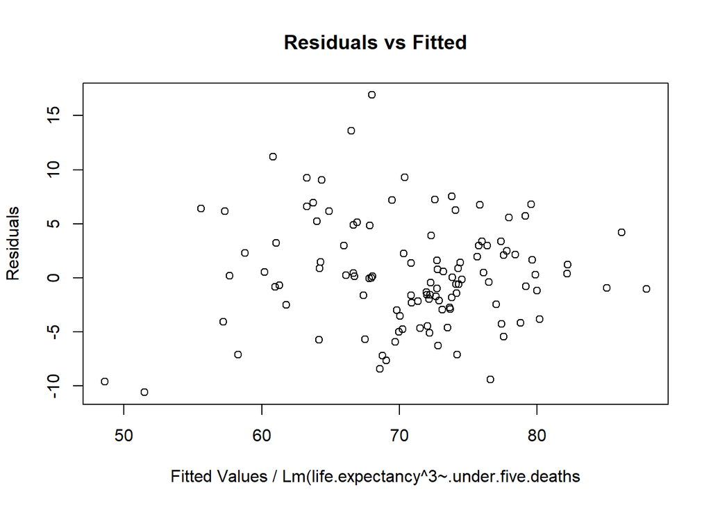

```r
# residuals vs fitted plot
plot(model_boxcox$fitted.values^(1/3),model_boxcox$fitted.values^(1/3)-train_data$Life.expectancy, xlab="Fitted Values / Lm(life.expectancy^3~.under.five.deaths", ylab="Residuals", main="Residuals vs Fitted")
```

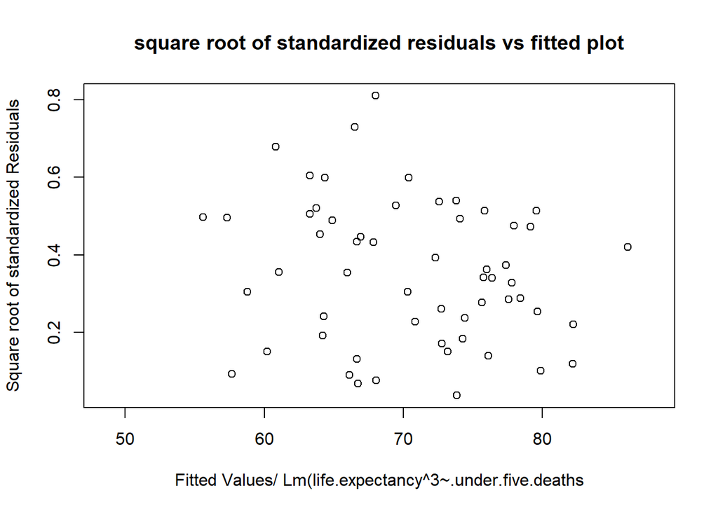

```r
# square root of standardized residuals vs fitted plot
residuals=model_boxcox$fitted.values^(1/3)-train_data$Life.expectancy
sigma_hat=sum(residuals^2)/(n_tr-(p_tr+1))
X=as.matrix(train_data[,c(-1,-2)])
his=diag(X%*%solve(t(X)%*%X)%*%t(X))
standardized_residuals=residuals/(sigma_hat*(1-his)^(1/2))
plot(model_boxcox$fitted.values^(1/3),standardized_residuals^(1/2), xlab="Fitted Values/ Lm(life.expectancy^3~.under.five.deaths", ylab="Square root of standardized Residuals", main="square root of standardized residuals vs fitted plot")
```

After Box Cox transformation, we find the heteroscadesticity disappeared, so we will retain it.

Because there is large collinearity in the predictors, we will do a criterion based variable selection. We will drop under.five.deaths because it it highly correlated with infant.deaths

```r
b = regsubsets(Life.expectancy^(3) ~ .-under.five.deaths, data=train_data)
summary(b)
```

```
## Subset selection object
## Call: regsubsets.formula(Life.expectancy^(3) ~ . - under.five.deaths,
##     data = train_data)
## 9 Variables  (and intercept)
##                  Forced in Forced out
## StatusDeveloping     FALSE      FALSE
## infant.deaths        FALSE      FALSE
## Alcohol              FALSE      FALSE
## Hepatitis.B          FALSE      FALSE
## BMI                  FALSE      FALSE
## Polio                FALSE      FALSE
## Diphtheria           FALSE      FALSE
## GDP                  FALSE      FALSE
## Schooling            FALSE      FALSE
## 1 subsets of each size up to 8
## Selection Algorithm: exhaustive
##          StatusDeveloping infant.deaths Alcohol Hepatitis.B BMI Polio
## 1  ( 1 ) " "              " "           " "     " "         " " " "
## 2  ( 1 ) " "              " "           " "     " "         " " " "
## 3  ( 1 ) " "              " "           " "     " "         "*" " "
## 4  ( 1 ) "*"              " "           " "     " "         "*" " "
## 5  ( 1 ) "*"              " "           "*"     " "         "*" " "
## 6  ( 1 ) "*"              " "           "*"     " "         "*" " "
## 7  ( 1 ) "*"              " "           "*"     "*"         "*" " "
## 8  ( 1 ) "*"              " "           "*"     "*"         "*" "*"
##          Diphtheria GDP Schooling
## 1  ( 1 ) " "        " " "*"
## 2  ( 1 ) " "        "*" "*"
## 3  ( 1 ) " "        "*" "*"
## 4  ( 1 ) " "        "*" "*"
## 5  ( 1 ) " "        "*" "*"
## 6  ( 1 ) "*"        "*" "*"
## 7  ( 1 ) "*"        "*" "*"
## 8  ( 1 ) "*"        "*" "*"
```

```r
rs <- summary(b)
aic <- n_tr*log(rs$rss/n_tr) + (2:9)*2
which.min(aic)
```

```
## [1] 5
```

```r
which.min(rs$bic)
```

```
## [1] 3
```

```r
which.max(rs$adjr2)
```

```
## [1] 7
```

```r
which.min(rs$cp)
```

```
## [1] 5
```

```r
model_1=lm(Life.expectancy^(3) ~ Status+Alcohol+BMI+GDP+Schooling, data=train_data)
summary(model_1)
```

```
##
## Call:
## lm(formula = Life.expectancy^(3) ~ Status + Alcohol + BMI + GDP +
##     Schooling, data = train_data)
##
## Residuals:
##     Min      1Q  Median      3Q     Max
## -176900  -53870    2720   48259  192541
##
## Coefficients:
##                    Estimate Std. Error t value Pr(>|t|)
## (Intercept)       4.478e+04  4.402e+04   1.017   0.3113
## StatusDeveloping -4.752e+04  2.501e+04  -1.900   0.0601 .
## Alcohol          -3.405e+03  2.372e+03  -1.436   0.1540
## BMI               7.565e+02  3.733e+02   2.026   0.0452 *
## GDP               1.169e+00  7.386e-01   1.583   0.1163
## Schooling         2.738e+04  3.442e+03   7.955    2e-12 ***
## ---
## Signif. codes:  0 '***' 0.001 '**' 0.01 '*' 0.05 '.' 0.1 ' ' 1
##
## Residual standard error: 69850 on 107 degrees of freedom
## Multiple R-squared:  0.6934, Adjusted R-squared:  0.6791
## F-statistic: 48.41 on 5 and 107 DF,  p-value: < 2.2e-16
```

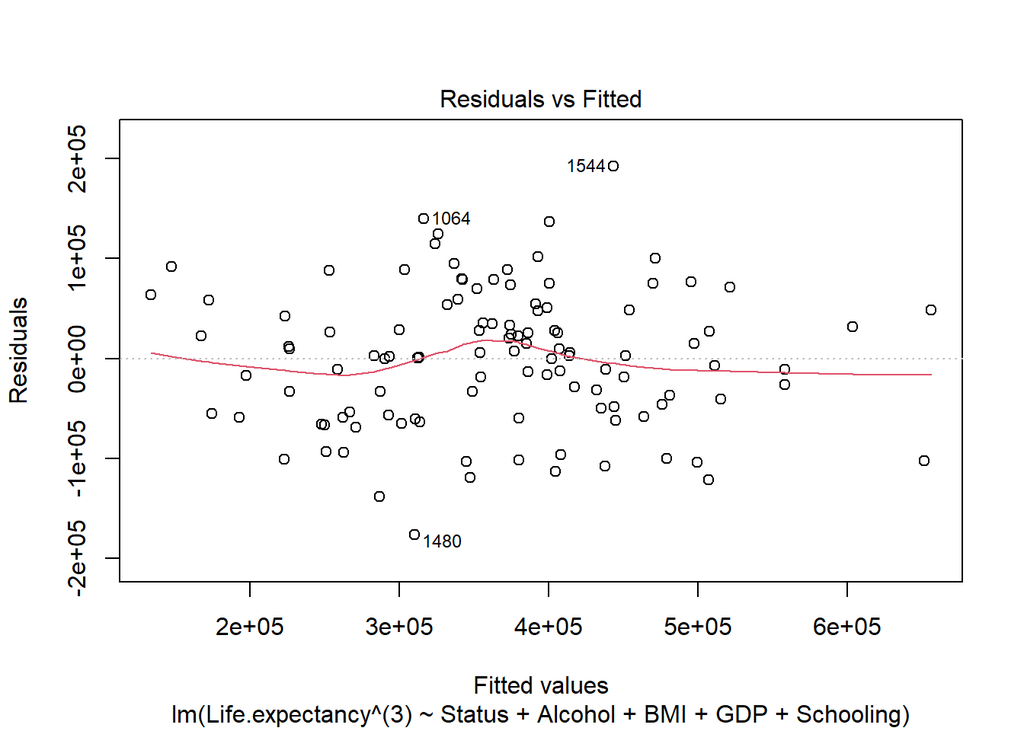

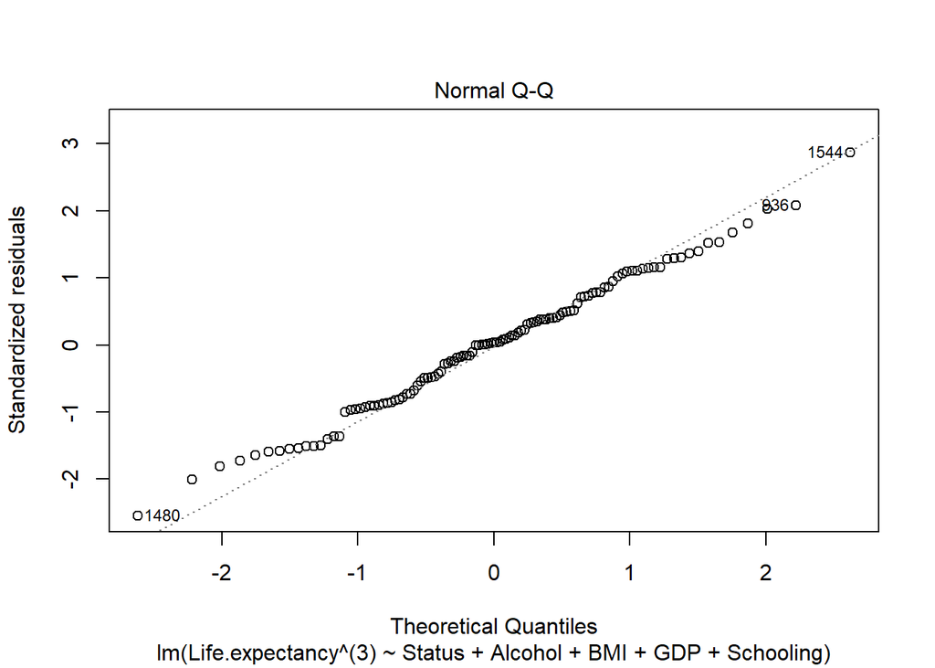

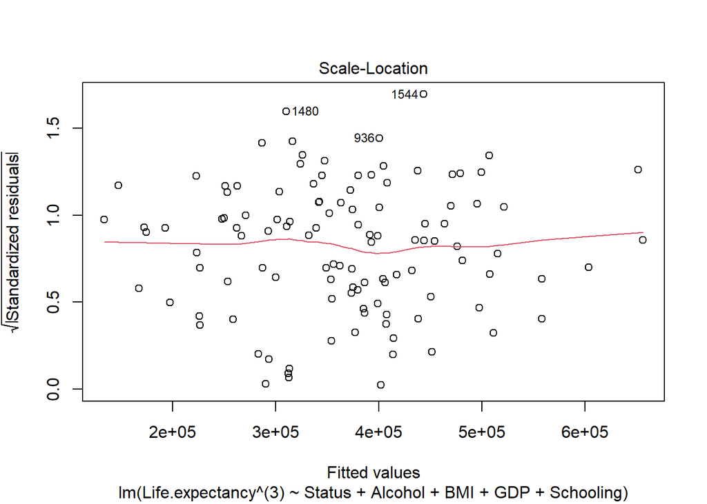

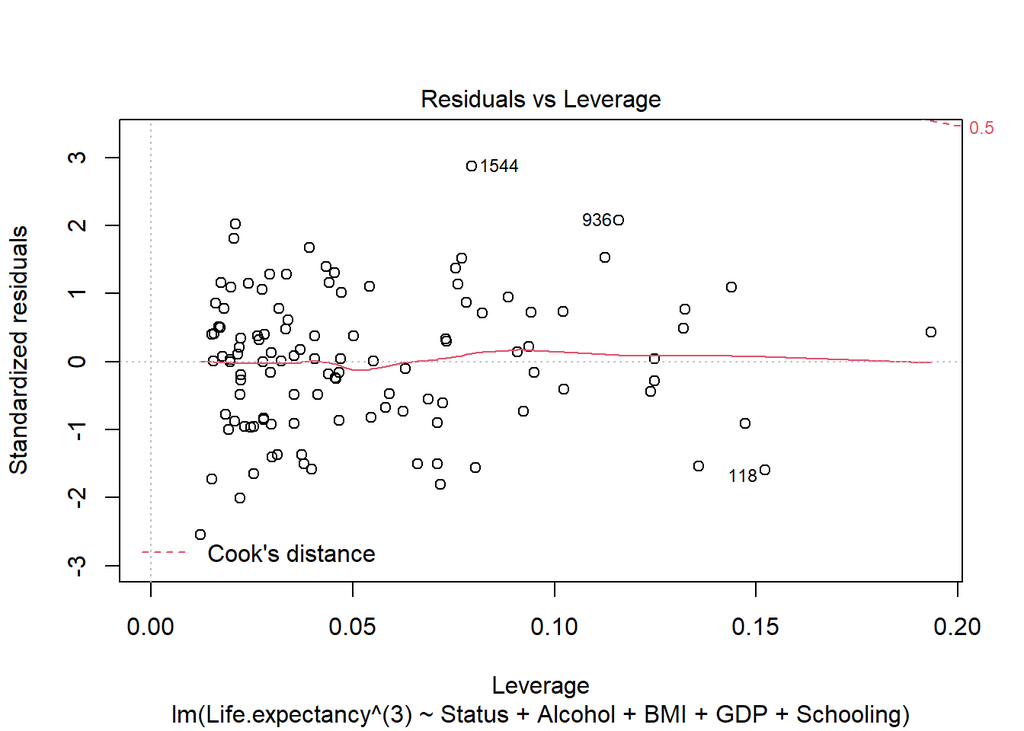

```r
plot(model_1)
```

```r
summary(lm(sqrt(abs(model_1$residuals))~model_1$fitted.value))
```

```
##
## Call:
## lm(formula = sqrt(abs(model_1$residuals)) ~ model_1$fitted.value)
##
## Residuals:
##     Min      1Q  Median      3Q     Max
## -206.50  -63.85   10.45   68.57  226.39
##
## Coefficients:
##                        Estimate Std. Error t value Pr(>|t|)
## (Intercept)           2.153e+02  3.371e+01   6.388 4.06e-09 ***
## model_1$fitted.value -6.565e-06  8.868e-05  -0.074    0.941
## ---
## Signif. codes:  0 '***' 0.001 '**' 0.01 '*' 0.05 '.' 0.1 ' ' 1
##
## Residual standard error: 96.38 on 111 degrees of freedom
## Multiple R-squared:  4.937e-05,  Adjusted R-squared:  -0.008959
## F-statistic: 0.00548 on 1 and 111 DF,  p-value: 0.9411
```

```r
model_2=lm(Life.expectancy^(3) ~ BMI+GDP+Schooling, data=train_data)
summary(model_2)
```

```
##
## Call:
## lm(formula = Life.expectancy^(3) ~ BMI + GDP + Schooling, data = train_data)
##
## Residuals:
##     Min      1Q  Median      3Q     Max
## -175863  -54494    2974   49901  207556
##
## Coefficients:
##               Estimate Std. Error t value Pr(>|t|)
## (Intercept) -1943.6384 31369.5532  -0.062   0.9507
## BMI           810.5933   374.5728   2.164   0.0326 *
## GDP             1.5955     0.7005   2.278   0.0247 *
## Schooling   26173.6372  2921.8613   8.958 1.01e-14 ***
## ---
## Signif. codes:  0 '***' 0.001 '**' 0.01 '*' 0.05 '.' 0.1 ' ' 1
##
## Residual standard error: 70520 on 109 degrees of freedom
## Multiple R-squared:  0.6817, Adjusted R-squared:  0.673
## F-statistic: 77.83 on 3 and 109 DF,  p-value: < 2.2e-16
```